# Forecasting NHL player performance

C. Bao

11/01/2015

# Introduction

The National Hockey League (NHL) is one of the premier professional hockey leagues in the world. Currently, there are 30 teams in NHL with average value of $490 million. Players are the most important assests of a hockey team. Being able to predict the performance of a player based on his previous season(s) and the statistics of similar players is not only important for the teams when they decide on multi-million dollar contracts, but also important for millions of fans who participate in the fantasy hockey leagues and private hockey pools. In this project, I plan to build a statistical model to forecast the performance of NHL players given past hockey statistics.

# Sources of Data

The data used for this document comes from Hockey Abstract (http://www.hockeyabstract.com/testimonials). It contains simple player statistics from 1967 to 2014 and advanced statistics from 2012 to 2015. For more completed and thorough studies in the future there are other sources of data available: Hockey database (http://www.opensourcesports.com/hockey/) contains more game oriented data dates back to the early 20th century. Wikipedia (https://en.wikipedia.org/wiki/Main_Page) contains player biographical information (height, weight, entry draft round and overall, etc.) which could be scraped. Game statistics can be found on the NHL website (http://www.nhl.com/ice/scores.htm?#navid=nav-scr-main) and player contract information can be found on various websites (http://nhlnumbers.com/, http://capfriendly.com/, https://www.hockeyscap.com/).

# Data Pre-processing

As the equipment technology and player capability develops throughout the time, the same sport has different characteristics in different eras. After the 2004-2005 NHL season lockout, the changes of rules and regulations result in new approach to the games where player speed is more emphasized than player size. Such changes give rise to different player statistics before and after the lockout. To predict the performance of current and future players in the NHL I only use data starting the 2005-2006 season in the simple hockey statistics data set for this preliminary study. I also group the left wing (LW) and right wing (RW) positions to one wing man (W) group due to symmetry and lack of statistical difference.

```r
library(dplyr)
library(gdata)
library(ggplot2)
data <- read.xls("source1/nhl_data_1967-2014.xls")
data$position <- data$Pos
levels(data$position) <- c("C","D","W","W")
data$season.year <- as.numeric(substr(as.character(data$Season),1,4))
post2004 <- filter(data,season.year > 2004)
```

For the advanced player statistics, I take the 2013-2014 season and 2014-2015 season data and cross reference them by player names. Only players which played more than 20 games in both seaons are included in this study. There are more detailed position descriptions of players in these datasets but for the purpose of this preliminary study I group them into forwards(F) which includes any combination of center(C),left wing(LW) and right wing(RW), defenseman(D) and switch(S) which includes the few cases where player played as both forward and defenseman during the season.

```r
data2013 <- read.xls("source1/nhl_player_2013-14.xls")
data2014 <- read.xls("source1/nhl_player_2014-15.xls")
data2013$Name <- paste(data2013$First.Name,data2013$Last.Name)
data2014$Name <- paste(data2014$First.Name,data2014$Last.Name)
crossdata <- merge(data2013,data2014,by.x="Name",by.y="Name")
crossdata$position <- crossdata$Pos.x
levels(crossdata$position) <- c("F","S","F","F","F","F","D","F","F","F","S","F","F","F","F","F","S","F","F")
regularplayer <- filter(crossdata,GP.x>=20,GP.y>=20)
```

# Exploratory Data Analysis

## Player performance as a function of age

As in many other professional team sports, it takes time for young players who just enter the league to adapt to playing systems, to gain physical maturity and to adapt to the speed and caliber of the game. So the expectation of the performance of rookie players and veteran players are different. The first preliminary question I want to address here is the dependence of player performance as a function of their age using the simple statistics data since 2005.

First let’s take a look at the distribution of player age breaking down by position. This is the combined distribution of all seasons so players who played more than one season contribute to multiple bins.

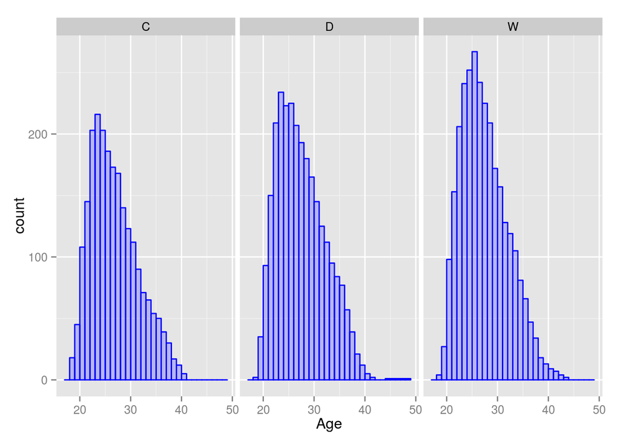

```r
p2 <- ggplot(post2004,aes(Age))
p2 <- p2 + geom_histogram(binwidth=1,col="blue",fill="blue",alpha=.2)
p2 <- p2 + facet_grid(. ~ position)
p2
```

As we can see from the histogram many NHL players enter the leagure in their low 20s and players above 40 years old are rare in the league. To get better statistics we only select players below 40 years old in this study. As a first approximation, we use total number of points (PTS) per season which is the sum of goals and assists as an indication of player performance.

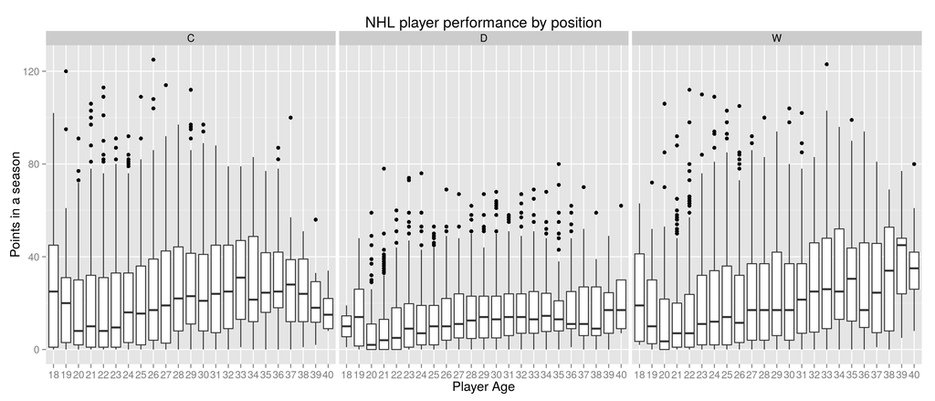

```r
post2004below40 <- filter(post2004,Age <=40)

p1 <- ggplot(post2004below40,aes(factor(Age),PTS))
p1 <- p1 + geom_boxplot()
p1 <- p1 + facet_grid(.~position)
p1 <- p1 + xlab("Player Age")+ylab("Points in a season")
p1 <- p1 + ggtitle("NHL player performance by position")
p1 <- p1 +theme(text = element_text(size=14),plot.title=element_text(size=16),axis.text=element_text(size=11))
p1
```

The decrease of player performance between 18 to 20 years of age comes from the fact that players enter the NHL at such young age are typically exceptional players which bias the statistics towards the higher value. Based on the plot above, players in all positions mature in their late 20s and early 30s. There is probably a bias toward more productive players since less performing players usually leave the league before they reach their late 20s. It is obvious there is a difference between the overall level of points between defensemen and forwards (C and W). This is expected: the primary responsibility of defensemen is not producing offense which is reflected in PTS.

## Correlation between player performance in consecutive seasons

Next question I want to investigate is whether there is any correlation between a player’s performance in consecutive seasons. I use the collection of players who played at least 20 games in each of the 2013-2014 and 2014-2015 season. To factor in the effect of missed game due to injuries and other reasons, I check the correlation between points per game played for each player.

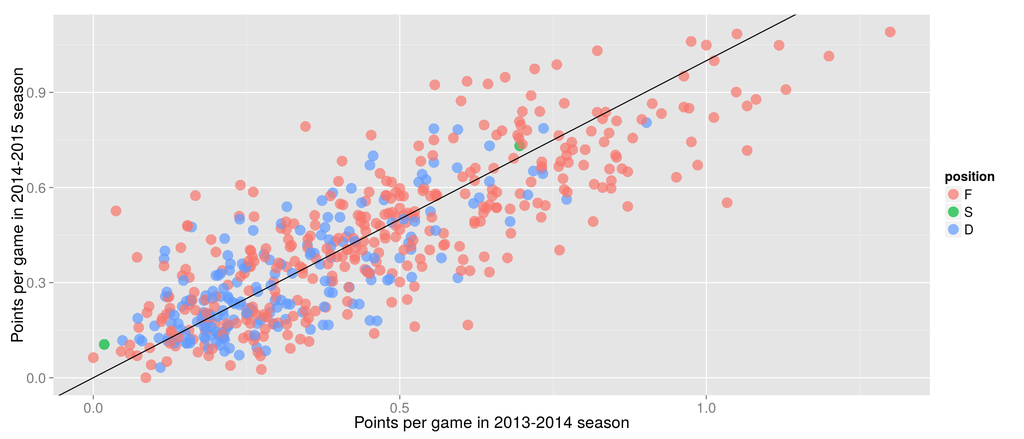

```r
p <- qplot(PTS.x/GP.x,PTS.y/GP.y,data=regularplayer,color=position,size=I(5),alpha=I(0.7))
p <- p+geom_abline(intercept=0,slope=1)
p <- p+xlab("Points per game in 2013-2014 season")
p <- p+ylab("Points per game in 2014-2015 season")
p <- p+theme(text = element_text(size=16),axis.text=element_text(size=14))
p
```

From the plot we can see there is a strong correlation between points per game during consecutive seasons. There is some spread around the correlation line nevertheless. For players above the line, they are overachieving in the 2014-2015 season compared to the 2013-2014 season and vice versa. This could be caused by the natural developing or declining of a player or just a fluke. Ultimately we want to identify players whose high/low performance during a season is just a statiscial abnormaly so their salary is calculated properly or they get selected at the proper spot in a fantasy league.

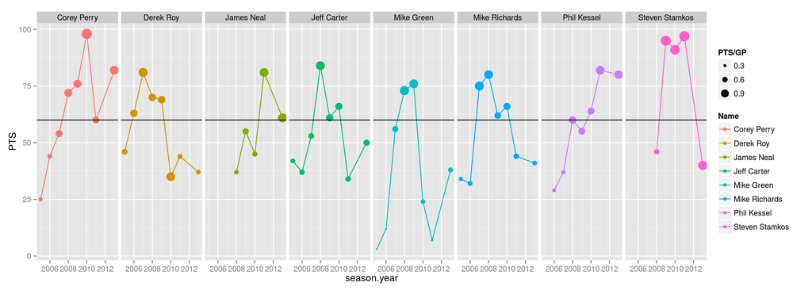

```r
post2004$Name <- paste(post2004$First.Name,post2004$Last.Name)
byplayer <- group_by(post2004,Name)
playerstat <- summarize(byplayer,maxpts=max(PTS),nyear=length(Season),entryage=min(Age),mingame=min(GP),maxptspgp=max(PTS/GP),diffptspgp=max(PTS/GP)-min(PTS/GP))
selectedplayers <- filter(playerstat,maxptspgp>=1.,maxptspgp<1.2,nyear>5,entryage <=22,mingame>20,diffptspgp>0.5)
selecteddata <- filter(post2004,Name %in% selectedplayers$Name, season.year!=2012)

p2 <- ggplot(selecteddata,aes(season.year,PTS))
p2 <- p2 + geom_point(aes(color=Name,size=PTS/GP))+geom_line(aes(color=Name))
p2 <- p2 + facet_grid(.~Name)
p2 <- p2 + scale_size(range=c(1,6))
p2 <- p2 + geom_hline(aes(yintercept=60))
p2
```

# Future Plans

The accurate forecast of NHL player performance has a big impact on NHL team decisions and hockey fans’ choice for their fantasy hockey league or private hockey pools. Based on the preliminary analysis I have shown there are statistical trends of player performance as they age, and correlation between player performance between consecutive seasons. For the next step of this project I plan to develop a predictive model to forecast player performance which factors in many variables such as size, age, salary, position, time on ice etc.